# Skúška - Valovič

```r
library(tidyverse)
library(car) #tento package potrebujem pre funkciu `leneveTest()`
diet.data <- read_csv("https://raw.githubusercontent.com/pavolvalovic/Skuska/master/diet.csv",col_names = TRUE, cols(
  Person = col_integer(),
  gender = col_integer(),
  Age = col_integer(),
  Height = col_integer(),
  pre.weight = col_integer(),
  Diet = col_character(),
  weight6weeks = col_double()
  )) #načítanie dát z GitHubu
diet.data$gender<-gsub(1,"M",diet.data$gender)
diet.data$gender<-gsub(0,"F",diet.data$gender)
diet.data <- mutate(diet.data,
       wloss = pre.weight-weight6weeks)
arrange(diet.data, Person)
```

```
## # A tibble: 78 x 8
##    Person gender   Age Height pre.weight Diet  weight6weeks wloss
##     <int> <chr>  <int>  <int>      <int> <chr>        <dbl> <dbl>
##  1      1 F         22    159         58 1             54.2  3.80
##  2      2 F         46    192         60 1             54    6
##  3      3 F         55    170         64 1             63.3  0.7
##  4      4 F         33    171         64 1             61.1  2.90
##  5      5 F         50    170         65 1             62.2  2.80
##  6      6 F         50    201         66 1             64    2
##  7      7 F         37    174         67 1             65    2
##  8      8 F         28    176         69 1             60.5  8.5
##  9      9 F         28    165         70 1             68.1  1.9
## 10     10 F         45    165         70 1             66.9  3.10
## # ... with 68 more rows
```

```r
View(diet.data)
```

Načítané dáta obsahujú informácie o 78 náhodne vybratých osobách, ktoré podstúpili 3 rôzne diéty (ozn. 1,2,3). Informácie zahŕňajú ich pohlavie, vek, výšku, hmotnosť pred diétou, typ diéty a hmotnosť po 6 týždňoch bežiacej diéty. Pre lepšiu prehľadnosť sme príkazom `gsub()` nahradili označenie pohlavia 0 a 1 za označenie F (female) a M (male). Príkazom `mutate()` sme vytvorili nový stĺpec **wloss**, ktorý sa rovná hmotnosť pred diétou *mínus* hmotnosť po diéte. Tabuľku sme nakoniec zoradili príkazom `arrange()` podľa poradového čísla osoby.

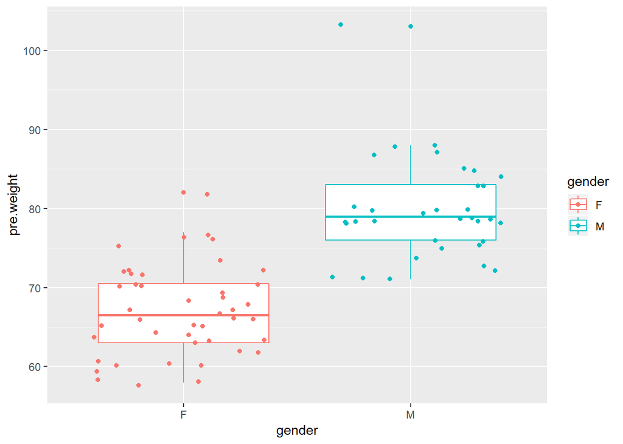

```r
ggplot(data = diet.data) +
  geom_boxplot(mapping = aes(x = gender, y = pre.weight, color = gender)) +
  geom_jitter(mapping = aes(x = gender, y = pre.weight, color = gender))
```

Pre prvý náhľad dát sme vykreslili hmotnosť pred diétou **pre.weight** pre obe pohlavia. Pre ďalšie testovania tieto hodnoty ani grafy význam nemajú, je však vhodné sa aspoň pozrieť na nakreslené dáta.

```r
diet.data <- select(diet.data, Person, gender, Diet, wloss)
arrange(diet.data, Person)
```

```
## # A tibble: 78 x 4
##    Person gender Diet  wloss
##     <int> <chr>  <chr> <dbl>
##  1      1 F      1      3.80
##  2      2 F      1      6
##  3      3 F      1      0.7
##  4      4 F      1      2.90
##  5      5 F      1      2.80
##  6      6 F      1      2
##  7      7 F      1      2
##  8      8 F      1      8.5
##  9      9 F      1      1.9
## 10     10 F      1      3.10
## # ... with 68 more rows
```

Keďže nás momentálne zaujíma iba jedinná premenná a tou je strata (presnejšie zmena) hmotnosti **wloss**, funkciou `select()` vyberieme z pôvodnej tabuľky iba stĺpce **Person**, pohlavie **gender**, druh diéty **Diet** a už spomínaný **wloss**.

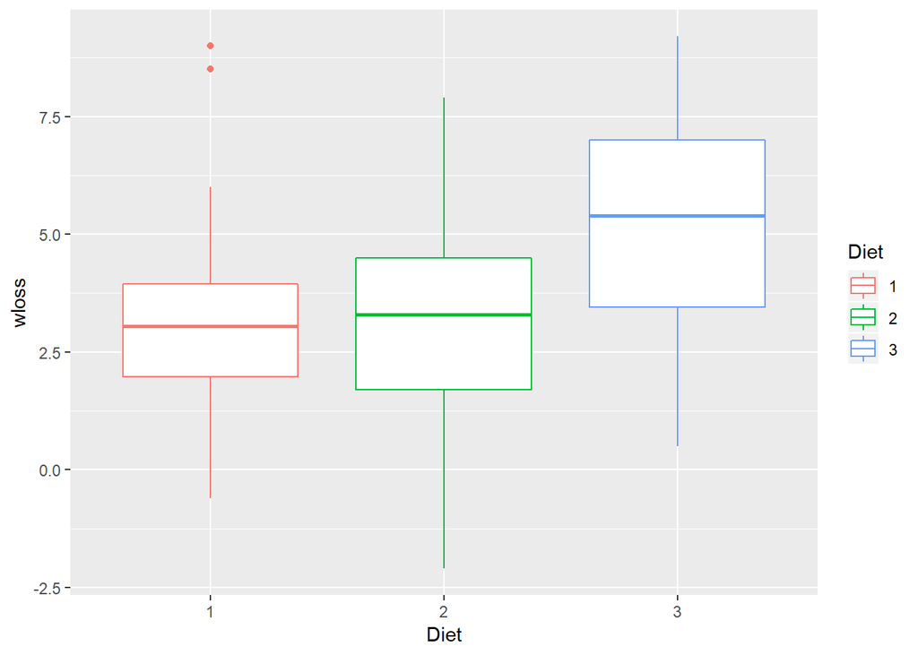

```r
ggplot(data = diet.data) +
  geom_boxplot(mapping = aes(x = Diet, y = wloss, color = Diet))
```

Na tomto grafe máme vykreslenú zmenu hmotnosti **wloss** pre 3 druhy diét. Na prvý pohľad je vidieť, že diéta 3 bola účinnejšia ako diéta 1 a 2, musíme však vhodným testom overiť, či je tento rozdiel aj štatisticky významný.

```r
library("ggpubr")
```

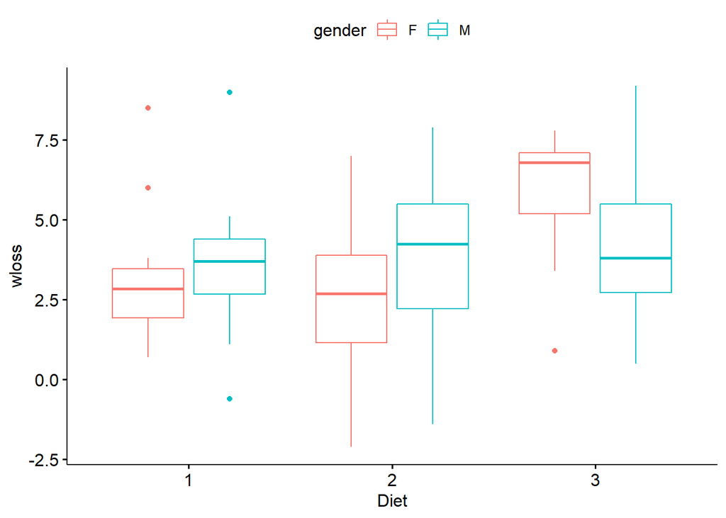

```r
ggboxplot(diet.data, x = "Diet", y = "wloss", color = "gender")
```

Tiež sa chceme pozrieť, či malo pohlavie vplyv na zmenu hmotnosti a či náhodou neexistuje interakcia medzi typom diéty a pohlavím.

Budeme používať analýzu rozptylu (2 way ANOVA).

```r
diet.fit <- aov(wloss ~ Diet + gender + Diet:gender, data=diet.data)
summary(diet.fit)
```

```
##             Df Sum Sq Mean Sq F value Pr(>F)
## Diet         2   71.1   35.55   6.428 0.0027 **
## gender       1    0.1    0.10   0.019 0.8914
## Diet:gender  2   31.9   15.96   2.887 0.0622 .
## Residuals   72  398.2    5.53
## ---
## Signif. codes:  0 '***' 0.001 '**' 0.01 '*' 0.05 '.' 0.1 ' ' 1
```

Použili sme funkciu `aov()` pre analýzu rozptylu. Test ukázal, že na hladine významnosti alfa = 5 % je rozdiel medzi troma typmi diét význnamný (p = 0.27 %). Zatiaž však ešte presne nevieme medzi ktorými skupinami. Taktiež sme zistili, že pohlavie nemá vplyv na **wloss** (p = 89.14 %) a taktiež na hladine významnosti 5 % nie je interakcia medzi druhom diéty a pohlavím (p = 6.22 %).

Na použitie tohto testu však treba splniť zopár predpokladov - dáta musia byť normálne rozdelené a musí byť splnená homogenita rozptylu v skupinách (t.j. rozptyl v každej skupine je rovnaký).

```r
leveneTest(wloss ~ Diet * gender, data = diet.data)
```

```
## Levene's Test for Homogeneity of Variance (center = median)
##       Df F value Pr(>F)
## group  5  0.5002 0.7751
##       72
```

Na overenie homogenity rozptylov sme použili Leveneov test, ktorý ukázal, že na hladine významnosti alfa = 5 % nie je rozdiel medzi rozptylmi signifikantný (p = 77.51 %) a teda je splnená podmienka o homogenite rozptylov.

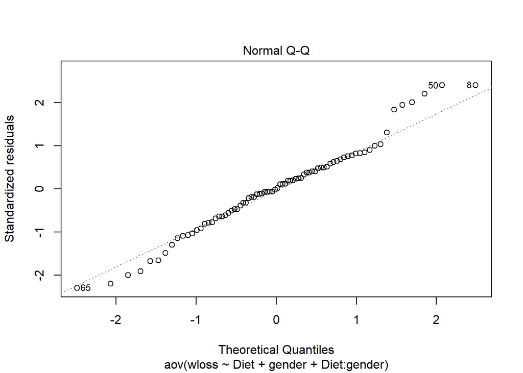

```r
plot(diet.fit, 2)
```

Vykreslili sme Q-Q graf rezíduí na overenie normality. Vidíme, že väčšina bodov leží na priamke normálneho rozdelenia, preto môžeme predpokladať že naše dáta sú tiež normálne rozdelené (aj keď pozorujeme pár outlierov, ktorí môžu spôsobiť problémy). Toto tvrdenie však podložíme patričným testom pre normalitu (Shapiro-Wilk).

```r
diet_residuals <- residuals(object = diet.fit)
shapiro.test(x = diet_residuals)
```

```
##
##  Shapiro-Wilk normality test
##
## data:  diet_residuals
## W = 0.98038, p-value = 0.2723
```

P hodnota 27 % nám hovorí, že na hladine významnosti 5 % nezamietame nulovú hypotézu, že dáta sú normálne rozdelené.

Na zistenie medziskupinových rozdielov použijeme Tukeyho HSD metódu pre viacnásobné porovnávania.

```r
TukeyHSD(diet.fit)
```

```
##   Tukey multiple comparisons of means
##     95% family-wise confidence level
##
## Fit: aov(formula = wloss ~ Diet + gender + Diet:gender, data = diet.data)
##
## $Diet
##           diff        lwr      upr     p adj
## 2-1 -0.2740741 -1.8528491 1.304701 0.9093774
## 3-1  1.8481481  0.2693732 3.426923 0.0177274
## 3-2  2.1222222  0.5905855 3.653859 0.0040477
##
## $gender
##           diff        lwr      upr     p adj
## M-F 0.07357398 -0.9968289 1.143977 0.8913971
##
## $`Diet:gender`
##               diff        lwr       upr     p adj
## 2:F-1:F -0.6166667 -3.1752393 1.9419060 0.9806879
## 3:F-1:F  2.8300000  0.2714273 5.3885727 0.0215884
## 1:M-1:F  0.6000000 -2.2506901 3.4506901 0.9895077
## 2:M-1:F  0.7166667 -1.9919056 3.4252390 0.9709342
## 3:M-1:F  1.1833333 -1.5252390 3.8919056 0.7953251
## 3:F-2:F  3.4466667  0.9325943 5.9607390 0.0019408
## 1:M-2:F  1.2166667 -1.5941517 4.0274850 0.8015705
## 2:M-2:F  1.3333333 -1.3332431 3.9999097 0.6879133
## 3:M-2:F  1.8000000 -0.8665764 4.4665764 0.3658724
## 1:M-3:F -2.2300000 -5.0408183 0.5808183 0.1985297
## 2:M-3:F -2.1133333 -4.7799097 0.5532431 0.1994866
## 3:M-3:F -1.6466667 -4.3132431 1.0199097 0.4672150
## 2:M-1:M  0.1166667 -2.8313445 3.0646778 0.9999969
## 3:M-1:M  0.5833333 -2.3646778 3.5313445 0.9920965
## 3:M-2:M  0.4666667 -2.3441517 3.2774850 0.9965189
```

Pozorným študovaním tabuľky viacnásobných porovnaní zisťujeme, že na hladine významnosti 5 % bola diéta 3 významne účinnejšia ako diéta 1 (p = 1.77 %) aj ako diéta 2 (p = 0.40 %). Taktiež sme potvrdili, že pohlavie nemalo vplyv na premennú **wloss** a že nie je pozorovaná žiadna interakcia medzi pohlavým a druhom diéty (toto sme už síce zistili predošlým testom, mám ale pocit, že je vhodné ukázať tento výsledok aj v tabuľke viacnásobných porovnaní aj za cenu mierneho “zoškaredenia” kódu a výstupu).